# Numerical Differentiation

## Contents

1. Imports
2. Differentiation
1. Differentiation Using Taylor Series
1. Forwards Difference
1. First Order Derivative
2. Second Order Derivative
3. First Order Derivative
4. Second Order Derivative
5. First Order Derivative
6. Second Order Derivative
2. Backwards Difference
3. Central Difference
2. Implementation with Examples
1. First Order Derivatives
1. Forward Difference
2. Backwards Difference
3. Central Difference
4. Forward Difference
5. Backwards Difference
6. Central Difference
2. Second Order Derivative
3. Comparison of the Different Methods
3. Other Methods
1. Richardson Extrapolation
2. Finite Divided Difference Approximation
4. Remarks

# Imports

```python
import numpy as np
import matplotlib.pyplot as plt
import timeit
from scipy.misc import derivative
```

# Differentiation

Differentiation of a function $f(x)$ is defined as: $$ \frac{df}{dx} = \lim_{h\to0} \frac{f(x+h) - f(x)}{h} $$

## Differentiation Using Taylor Series

Taylor series gives a mean of approximationa function on a point $x+h$ (here denoted by $x_{i+1}$) as the value the function at $x$ and its derivative at $x$. The Taylor series is: $$ f(x_{i+1}) = f(x_i) + \frac{f'(x_i) (x_{i+1}-x_i)}{1!} + \frac{f''(x_i) (x_{i+1}-x_i)^2}{2!} + \cdots + \frac{f^{(n)}(x_i) (x_{i+1}-x_i)^n}{n!}+\cdots $$

Using the above formula, the derivative of a function can be approximated.

### Forwards Difference

#### First Order Derivative

Forward difference formula for the first order derivative is: $$ f'(x_i) = \frac{-f(x_{i+2}) + 4f(x_{i+1}) - 3f(x_i)}{2h} + O(h^2) $$

The above relation has an error of order $h^2$.

#### Second Order Derivative

The second order derivative is: $$ f''(x_i) = \frac{-f(x_{i+3}) + 4f(x_{i+2}) - 5f(x_{i+1}) + 2f(x_i)}{h^2} + O(h^2) $$

Again, the error is of order $h^2$.

### Backwards Difference

#### Second Order Derivative

The second order derivative is: $$ f''(x_i) = \frac{2f(x_{i}) -5f(x_{i-1}) + 4f(x_{i-2}) -f(x_{i-3})}{h^2} + O(h^2) $$

### Central Difference

The central difference formula can also be derived from Taylor expansion.

#### First Order Derivative

The first order derivative is: $$ f'(x_i) = \frac{f(x_{i+1}) - f(x_{i-1})}{2h} + O(h^2) $$ here the error is of order $h^2$.

We can also derive a formula with the error of order $h^4$. The formula is: $$ f'(x_i) = \frac{-f(x_{i+2})+8f(x_{i+1}) -8f(x_{i-1})+f(x_{i-2})}{12h} + O(h^4) $$

#### Second Order Derivative

A formula for second order derivative is with an error of $O(h^2)$ is: $$ f''(x_i) = \frac{f(x_{i+1}) - 2f(x_{i}) + f(x_{i-1})}{h^2} + O(h^2) $$

While, for error of order $h^4$, the formula is: $$ f''(x_i) = \frac{-f(x_{i+2}) + 16f(x_{i+1}) - 30f(x_{i}) + 16f(x_{i-1}) -f(x_{i-2})}{12h^2} + O(h^4) $$

## Implementation with Examples

We'll be using the function $$ f(x) = x^2 + sin(x) $$ At $x=0.5$. The derivative of it, analytically is: $$ f'(x) = 2x + cos(x) $$ Which , for $x=0.5$, is 1.8775825618903728.

Also, the second derivative is: $$ f''(x) = 2 -sin(x) $$ which, at $x=0.5$, is 1.520574461395797.

```python
def f(x):
    return x**2 + np.sin(x)

def fbarx(x):
    return 2*x + np.cos(x)

def fdoublebarx(x):
    return 2 - np.sin(x)
```

```python
plt.rcdefaults()
```

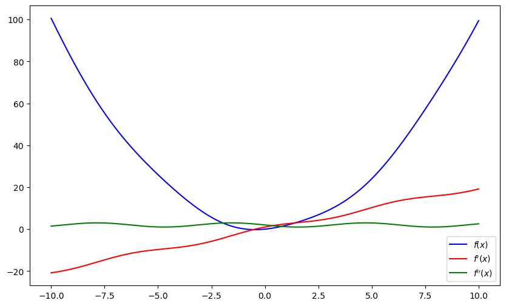

```python
X = np.linspace(-10, 10, 1000)
Y = f(X)
Ybar = fbarx(X)
Ydoublebar = fdoublebarx(X)
plt.figure(figsize=(10,6))
plt.plot(X, Y, label='$f(x)$', color='blue')
plt.plot(X, Ybar, label='$f\'(x)$', color='red')
plt.plot(X, Ydoublebar, label='$f\'\'(x)$', color='green')
plt.legend()
plt.show()
```

```python
#error
def error(y_calc, x=0.5, fdoublebar = False):
    if fdoublebar:
        y_true = fdoublebarx(x)
    else:
        y_true = fbarx(x)
    absolute_error = np.abs(y_true - y_calc)
    relative_error = absolute_error / y_true
    return absolute_error, relative_error
```

### First Order Derivatives

#### Forward Difference

```python
#O(h) Implementaion
def oh(f, x, h=1e-3, report_error = True):
    y_calc = (f(x+h) - f(x))/(h)
    if report_error:
        ae, re = error(y_calc, x)
        print("Absolute Error:", ae)
        print("Relative Error:", re)
        return y_calc
    else:
        return y_calc
oh(f, 0.5)
```

```
Absolute Error: 0.0007601409868609466
Relative Error: 0.00040485089832514604
```

```
1.8783427028772337
```

```python
#O(h2) Implementation of the Forward Difference
def fdoh2(f, x, h=1e-3, report_error = True):
    numerator = -f(x+2*h) + 4*f(x+h) - 3*f(x)
    denominator = 2*h
    y_calc = numerator/denominator
    if report_error:
        ae, re = error(y_calc, x)
        print("Absolute Error:", ae)
        print("Relative Error:", re)
        return y_calc
    else:
        return y_calc
```

```python
fdoh2(f, 0.5, h=1e-3)
```

```
Absolute Error: 2.9240747068115525e-07
Relative Error: 1.5573614530524607e-07
```

```
1.8775828542978434
```

#### Backwards Difference

```python
#backward difference
def bdoh2(f, x, h=1e-3, report_error = True):
    numerator = 3*f(x) - 4*f(x-h) + f(x-2*h)
    denominator = 2*h
    y_calc = numerator/denominator
    if report_error:
        ae, re = error(y_calc, x)
        print("Absolute Error:", ae)
        print("Relative Error:", re)
        return y_calc
    else:
        return y_calc
bdoh2(f, 0.5, h=1e-3)
```

```
Absolute Error: 2.9264722334332305e-07
Relative Error: 1.558638375127868e-07
```

```
1.877582854537596
```

#### Central Difference

```python
# central difference O(h2)
def cdoh2(f, x, h=1e-3, report_error = True):
    numerator = f(x+h) - f(x-h)
    denominator = 2*h
    y_calc = numerator/denominator
    if report_error:
        ae, re = error(y_calc, x)
        print("Absolute Error:", ae)
        print("Relative Error:", re)
        return y_calc
    else:
        return y_calc

cdoh2(f, 0.5, h=1e-3)
```

```
Absolute Error: 1.4626379529758538e-07
Relative Error: 7.790006057061226e-08
```

```
1.8775824156265775
```

```python
#central difference O(h4)
def cdoh4(f, x, h=1e-3, report_error = True):
    numerator = -f(x+2*h) + 8*f(x+h) - 8*f(x-h) + f(x-2*h)
    denominator = 12*h
    y_calc = numerator/denominator
    if report_error:
        ae, re = error(y_calc, x)
        print("Absolute Error:", ae)
        print("Relative Error:", re)
        return y_calc
    else:
        return y_calc
cdoh4(f, 0.5, h=1e-3)
```

```
Absolute Error: 4.418687638008123e-14
Relative Error: 2.353391924112959e-14
```

```
1.8775825618903286
```

### Second Order Derivative

#### Forward Difference

```python
# forward difference O(h2)
def fdoh2second(f, x, h=1e-3, report_error = True):
    numerator = -f(x+3*h) + 4*f(x+2*h) - 5*f(x+h) + 2*f(x)
    denominator = h**2
    y_calc = numerator/denominator
    if report_error:
        ae, re = error(y_calc, x, fdoublebar=True)
        print("Absolute Error:", ae)
        print("Relative Error:", re)
        return y_calc
    else:
        return y_calc
fdoh2second(f, 0.5, h=1e-3)
```

```
Absolute Error: 4.400327222597866e-07
Relative Error: 2.8938584293719016e-07
```

```
1.5205740213630747
```

#### Backwards Difference

```python
# backward difference O(h2) second order
def bdoh2second(f, x, h=1e-3, report_error = True):
    numerator = 2*f(x) - 5*f(x-h) +4*f(x-2*h) - f(x-3*h)
    denominator = h**2
    y_calc = numerator/denominator
    if report_error:
        ae, re = error(y_calc, x, fdoublebar=True)
        print("Absolute Error:", ae)
        print("Relative Error:", re)
        return y_calc
    else:
        return y_calc

bdoh2second(f, 0.5, h=1e-3)
```

```
Absolute Error: 4.3881147693269895e-07
Relative Error: 2.8858269560169784e-07
```

```
1.52057402258432
```

#### Central Difference

```python
#central difference O(h2) second order
def cdoh2second(f, x, h=1e-3, report_error = True):
    numerator = f(x+h) - 2*f(x) + f(x-h)
    denominator = h**2
    y_calc = numerator/denominator
    if report_error:
        ae, re = error(y_calc, x, fdoublebar=True)
        print("Absolute Error:", ae)
        print("Relative Error:", re)
        return y_calc
    else:
        return y_calc
cdoh2second(f, 0.5, h=1e-3)
```

```
Absolute Error: 3.991669128566855e-08
Relative Error: 2.6251059911283398e-08
```

```
1.5205745013124883
```

```python
#central difference O(h4) second order
def cdoh4second(f, x, h=1e-3, report_error = True):
    numerator = -f(x+2*h) + 16*f(x+h) - 30*f(x) + 16*f(x-h)- f(x-2*h)
    denominator = 12*h**2
    y_calc = numerator/denominator
    if report_error:
        ae, re = error(y_calc, x, fdoublebar=True)
        print("Absolute Error:", ae)
        print("Relative Error:", re)
        return y_calc
    else:
        return y_calc
cdoh4second(f, 0.5, h=1e-3)
```

```
Absolute Error: 1.4295142847231546e-10
Relative Error: 9.401146218192731e-11
```

```
1.5205744615387484
```

### Comparison of the Different Methods

The central difference is clearly more accurate than the forward and backwards difference. Let's see if it is faster too?

```python
oh_time = timeit.timeit(stmt="oh(f, 0.5, report_error=False)", number=100000, setup="from __main__ import oh, f")
fdoh2_time = timeit.timeit(stmt="fdoh2(f, 0.5, report_error=False)", number=100000, setup="from __main__ import fdoh2, f")
bdoh2_time = timeit.timeit(stmt="bdoh2(f, 0.5, report_error=False)", number=100000, setup="from __main__ import bdoh2, f")
cdoh2_time = timeit.timeit(stmt="cdoh2(f, 0.5, report_error=False)", number=100000, setup="from __main__ import cdoh2, f")
cdoh4_time = timeit.timeit(stmt="cdoh4(f, 0.5, report_error=False)", number=100000, setup="from __main__ import cdoh4, f")
sp_time = timeit.timeit(stmt="derivative(f, 0.5, dx=1e-3)", number=100000, setup="from __main__ import derivative, f")
```

```python
oh_time, fdoh2_time, bdoh2_time, cdoh2_time, cdoh4_time, sp_time
```

```
(0.6321755000000167,
 1.0214599999999905,
 0.9381749000000354,
 0.6445823999999902,
 1.2573420999999598,
 4.404312899999979)
```

```python
oh_time = timeit.timeit(stmt="oh(f, 0.5, report_error=False)", number=100000, setup="from __main__ import oh, f")
fdoh2_time = timeit.timeit(stmt="fdoh2(f, 0.5, report_error=False)", number=100000, setup="from __main__ import fdoh2, f")
bdoh2_time = timeit.timeit(stmt="bdoh2(f, 0.5, report_error=False)", number=100000, setup="from __main__ import bdoh2, f")
cdoh2_time = timeit.timeit(stmt="cdoh2(f, 0.5, report_error=False)", number=100000, setup="from __main__ import cdoh2, f")
cdoh4_time = timeit.timeit(stmt="cdoh4(f, 0.5, report_error=False)", number=100000, setup="from __main__ import cdoh4, f")
sp_time = timeit.timeit(stmt="derivative(f, 0.5, dx=1e-3)", number=100000, setup="from __main__ import derivative, f")
oh_time, fdoh2_time, bdoh2_time, cdoh2_time, cdoh4_time, sp_time
```

```
(0.7947380999999609,
 1.382966500000009,
 1.4363558000000012,
 0.9500264999999786,
 1.7992227000000298,
 4.637720700000045)
```

```python
error(derivative(f, 0.5, dx=1e-3), 0.5), error(cdoh2(f, 0.5, report_error=False))
```

```
((1.4626379529758538e-07, 7.790006057061226e-08),
 (1.4626379529758538e-07, 7.790006057061226e-08))
```

Error are the same in both the methods.

## Other Methods

### Richardson Extrapolation

Richardson extrapolation uses two derivative estimates to compute a third, more accurate approximation. For example, we can use two values for h to compute the derivative which is more accurate than the original estimate. For centered difference approximations with $O(h_2)$, the application of this formula will yield a new derivative estimate of $O(h_4)$. We use: $$ D = \frac{4}{3}D(h_1)-\frac{1}{3}D(h_2) $$ with $h_1<h_2$. Let's see an example:

```python
cdoh2(f, 0.5,0.1)
cdoh2(f, 0.5,0.2)
```

```
Absolute Error: 0.0014619064584484587
Relative Error: 0.0007786110119049006
Absolute Error: 0.005838860449494332
Relative Error: 0.003109775606147352
```

```
1.8717437014408784
```

```python
dh1 = cdoh2(f, 0.5, h=0.1, report_error=False)
dh2 = cdoh2(f, 0.5, h=0.2, report_error=False)
D = 4*dh1/3 - dh2/3
error(D, 0.5)
```

```
(2.921794766352903e-06, 1.5561471573378936e-06)
```

```python
dh1 = cdoh2(f, 0.5, h=0.01)
dh2 = cdoh2(f, 0.5, h=0.02)
```

```
Absolute Error: 1.4626302896392218e-05
Relative Error: 7.789965242149607e-06
Absolute Error: 5.850433402154742e-05
Relative Error: 3.115939357822143e-05
```

```python
dh1 = cdoh2(f, 0.5, h=0.02, report_error=False)
dh2 = cdoh2(f, 0.5, h=0.01, report_error=False)
D = 4*dh2/3 - dh1/3
error(D, 0.5)
```

```
(2.9252156252823625e-10, 1.5579691059429205e-10)
```

We can see that we get a better approximation of the derivative with Richardson extrapolation.

## Remarks

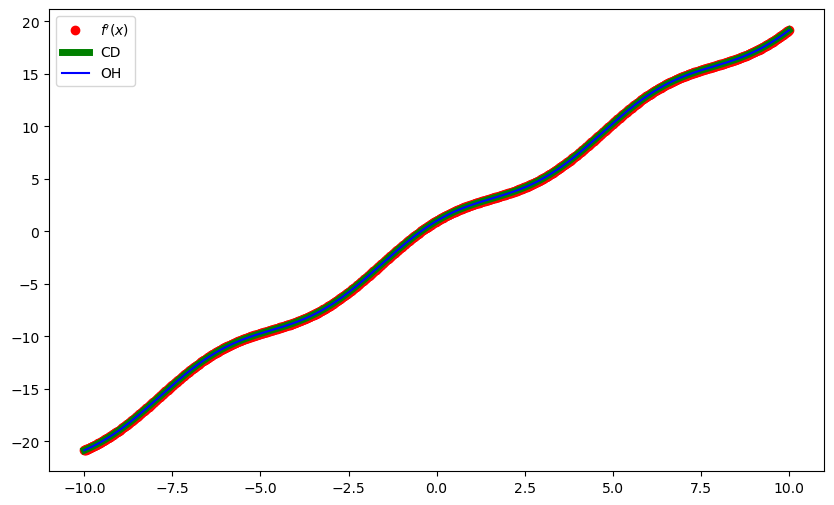

```python
def compare(f, fbar):
    X = np.linspace(-10, 10, 1000)
    Ybar = fbar(X)
    Ybar2 = cdoh2(f, X, h=0.1, report_error=False)
    Ybar3 = oh(f, X, report_error=False)
    plt.figure(figsize=(10,6))
    plt.plot(X, Ybar, "o" ,label='$f\'(x)$', color='red')
    plt.plot(X, Ybar2, label='CD', color='green', linewidth=5)
    plt.plot(X, Ybar3, label='OH', color='blue')
    plt.legend()
    plt.show()
compare(f, fbarx)
```

Let's use some more functions.

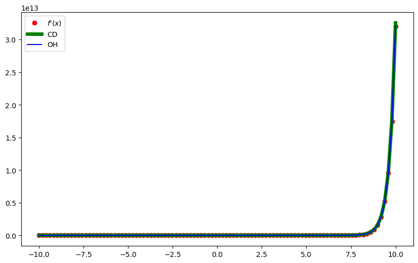

```python
def f2(x):
    return np.exp(3*x)
def f2bar(x):
    return 3*np.exp(3*x)
compare(f2, f2bar)
```

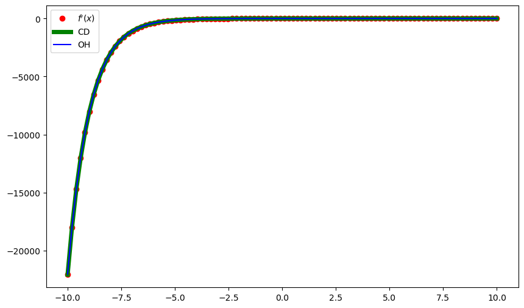

```python
f3 = lambda x: np.sin(x)+np.cos(x)+np.exp(-x)
f3bar = lambda x: np.cos(x)-np.sin(x)-np.exp(-x)
compare(f3, f3bar)
```

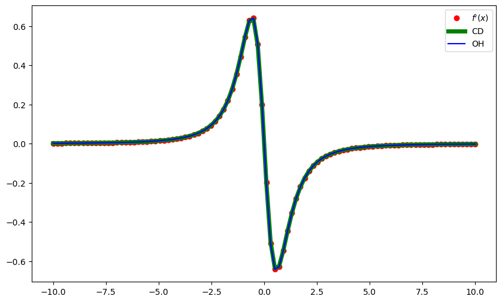

```python
f4 = lambda x: 1/(1+x**2)
f4bar = lambda x: -2*x/(1+x**2)**2
compare(f4, f4bar)
```

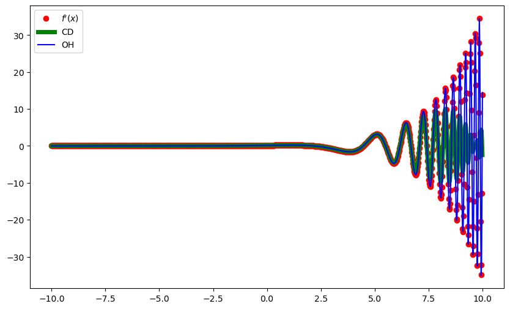

```python
a = 1
f4 = lambda x: np.sin(np.sqrt((np.exp(x)+a))/2)
f4bar = lambda x: ((np.exp(x))*(np.cos(np.sqrt((np.exp(x)+a))/2)))/(4*np.sqrt((np.exp(x)+a)))
compare(f4, f4bar)
```